# PAML Plotting

Chandni Shaw Gupta

4/28/2021

```r
library(tidyverse)
```

```r
library(cowplot)  # For theme
library(lubridate)
library(ggsci)
library(ggrepel)
library(ggplot2)
```

#M7 Site Model

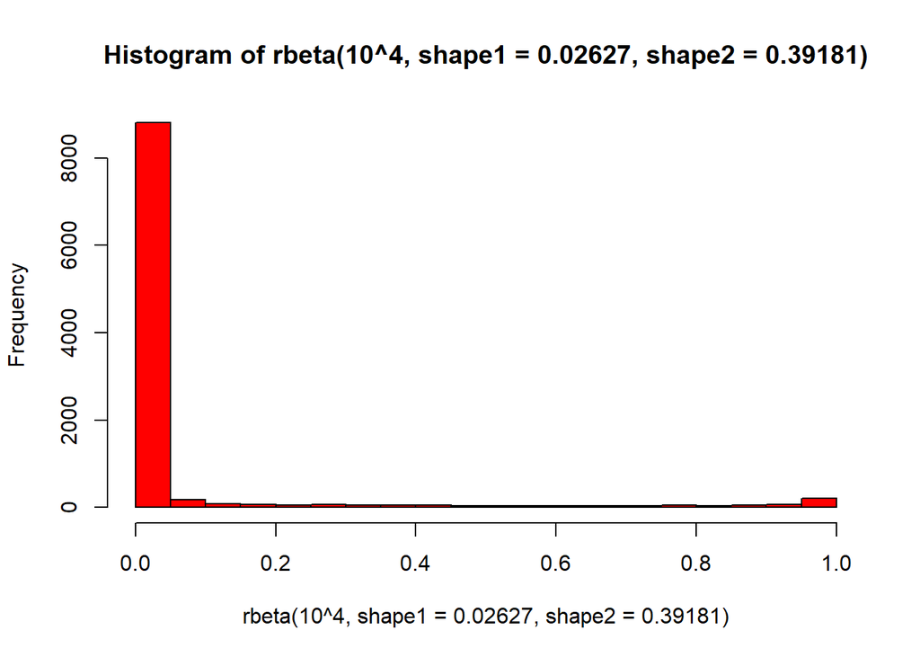

```r
hist(rbeta(10^4, shape1 = 0.02627, shape2 = 0.39181),col="red")
```

#M8 Site Model

```r
M8 <- tibble(     proportion = c(0.09861,  0.09861,  0.09861,  0.09861,  0.09861,  0.09861,  0.09861,  0.09861,  0.09861,  0.09861,  0.01390),
                  omega = c(0.00000,  0.00000,  0.00000,  0.00000,  0.00000,  0.00002,  0.00032,  0.00364,  0.03140,  0.23811,  3.46433))
knitr::kable(M8,align = "c",col.names = c("proportion","omega"))
```

| proportion | omega |
| --- | --- |
| 0.09861 | 0.00000 |
| 0.09861 | 0.00000 |
| 0.09861 | 0.00000 |
| 0.09861 | 0.00000 |
| 0.09861 | 0.00000 |
| 0.09861 | 0.00002 |
| 0.09861 | 0.00032 |
| 0.09861 | 0.00364 |
| 0.09861 | 0.03140 |
| 0.09861 | 0.23811 |
| 0.01390 | 3.46433 |

#Dotplot

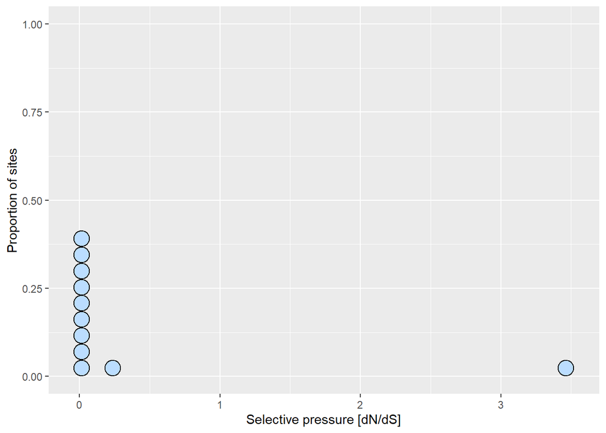

```r
ggplot(data = M8, aes(x=omega)) +
  geom_dotplot(fill = "#BBDDFF") +
  xlab("Selective pressure [dN/dS]") +
  ylab("Proportion of sites")
```

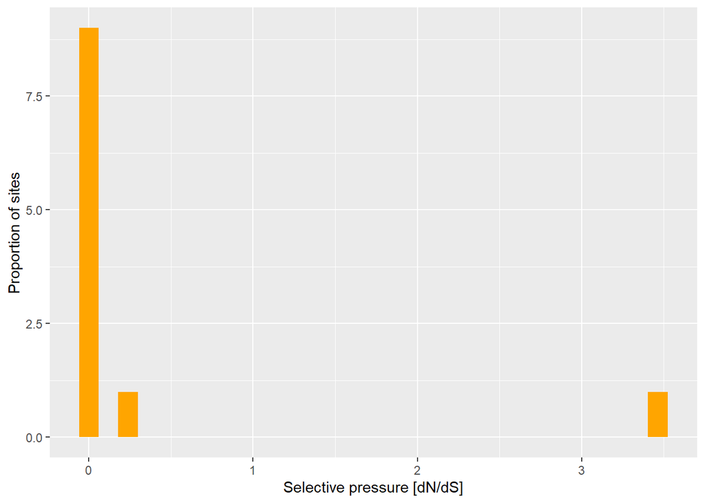

```r
ggplot(data = M8, aes(x=omega)) +
  geom_histogram(fill = "orange") +
  xlab("Selective pressure [dN/dS]") +
  ylab("Proportion of sites")
```

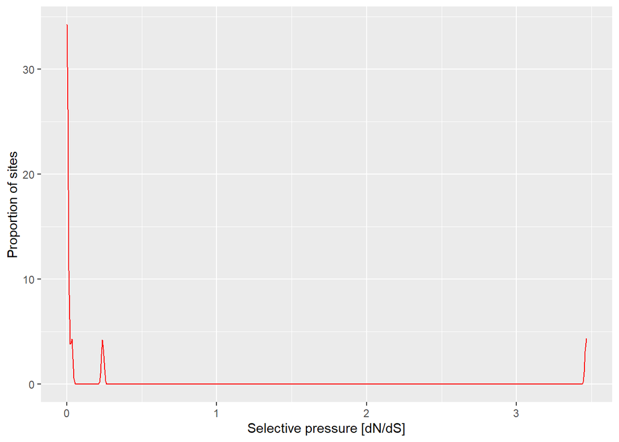

```r
ggplot(data = M8, aes(x=omega)) +
  geom_density(kernel = "gaussian", color = 'red') +
  xlab("Selective pressure [dN/dS]") +
  ylab("Proportion of sites")
```

#For visualiztion of sites and their estimated dN/dS ratio

```r
df<-read.table("C:/Users/awila/OneDrive/Documents/GitHub/MScThesis/R/bebsm.txt", sep = "")
```

```r
df$beb <- "No"
df$beb[df$V13 > 0.50] <- "Yes"
```

NOte: 3rd to 13th column = BEB score for each class (10 neutral + 1 allowing positive selection).

#dN/dS ratio for amino acid sites in whole S gene with RBD region marked

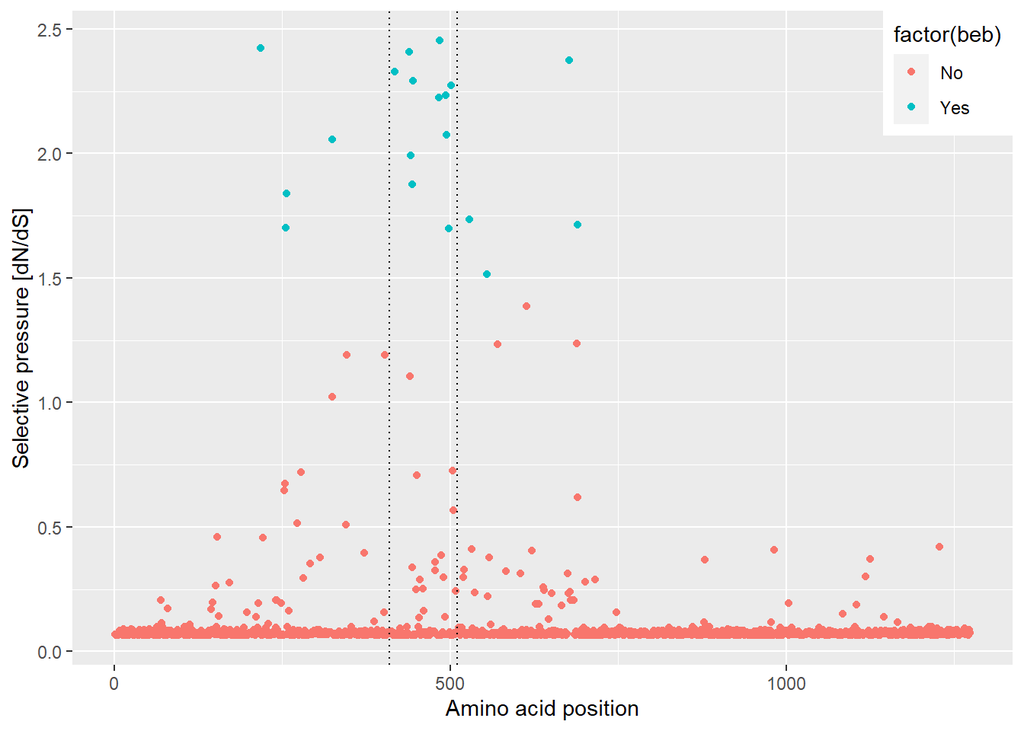

```r
ggplot(df, aes(V1, V15)) +
  geom_point(aes(colour = factor(beb)))+
  geom_vline(xintercept = c(410,510), linetype="dotted")+
   xlab("Amino acid position") +
     ylab("Selective pressure [dN/dS]") +
    #ggtitle("Sites which have posterior probabilty > 50% of M8 Site Model") +
theme(legend.position = c(1,1),
        legend.justification = c(1,1))+
  NULL
```

```r
ggsave("C:/Users/awila/OneDrive/Documents/GitHub/MScThesis/R/plots/bebsmpointwholeSgenewithRBD.png", height=4, width=7)
```

Note: We see that most sites are under strong purifying selection and the sites under positive selection represent only a small fraction.

#For visualiztion of rst file of baseml for M8 site model

```r
df1<-read.csv("C:/Users/awila/OneDrive/Documents/GitHub/MScThesis/R/rstfilefrombaseml.csv", sep=",")
```

```r
names(df1)
```

```
##  [1] "Starting.Seq.Index"                 "Ending.Seq.Index"
##  [3] "Base.Position.of.Change"            "Starting.Base"
##  [5] "Ending.Base"                        "Transition.or.Transversion"
##  [7] "Change.codon.Position"              "Corresponding.codon.Start.Pos"
##  [9] "Change.Pair"                        "Starting.NT.codon"
## [11] "Starting.NT.codon.with.Base.Change" "Ending.NT.codon.2"
## [13] "Synonymous.or.NonSynonymous"        "AminoAcid1"
## [15] "IntermedAmino"                      "AminoAcid2"
## [17] "AAChg"
```

```r
df2 <- df1[order(df1$Corresponding.codon.Start.Pos),]
```

#count of transitions and transversions

```r
df2$fTransition.or.Transversion <- factor(df2$Transition.or.Transversion)
subdata <- subset(df2, Transition.or.Transversion %in% c("ts", "tv"))
```

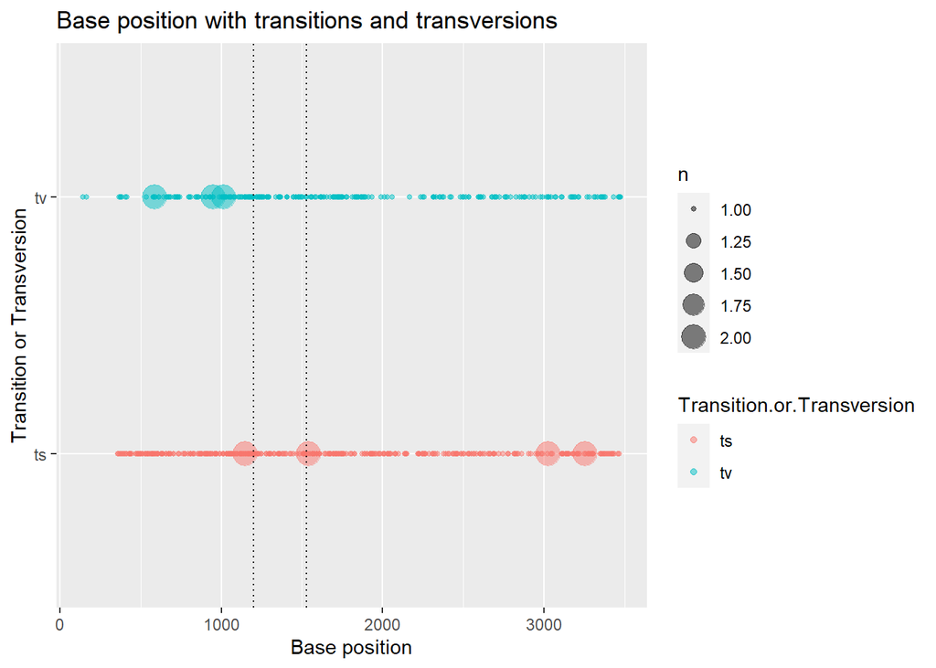

```r
ggplot(data = df2, aes(x=Base.Position.of.Change, y=Transition.or.Transversion, color=Transition.or.Transversion)) +
  geom_count(alpha=0.5)+
  geom_vline(xintercept = c(1200,1530), linetype="dotted")+
   xlab("Base position") +
     ylab("Transition or Transversion") +
    ggtitle("Base position with transitions and transversions") +
  NULL
```

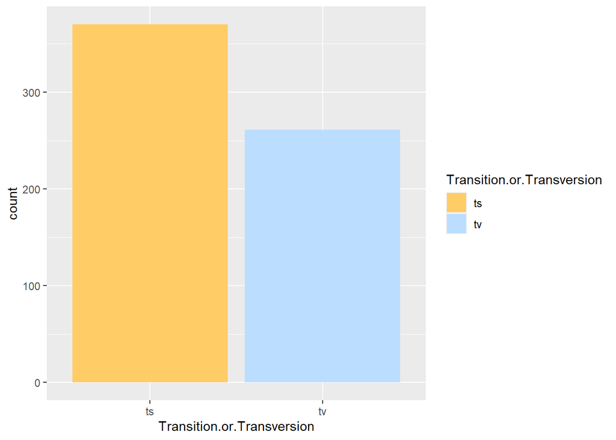

```r
ggplot(data = df2, aes(x=Transition.or.Transversion, fill=Transition.or.Transversion)) +
  geom_bar()+
  scale_fill_manual(values = c("#FFCC66", "#BBDDFF"))
```

```r
df2$fSynonymous.or.NonSynonymous <- factor(df2$Synonymous.or.NonSynonymous)
subdata1 <- subset(df2, Synonymous.or.NonSynonymous %in% c("syn", "nonsyn"))
```

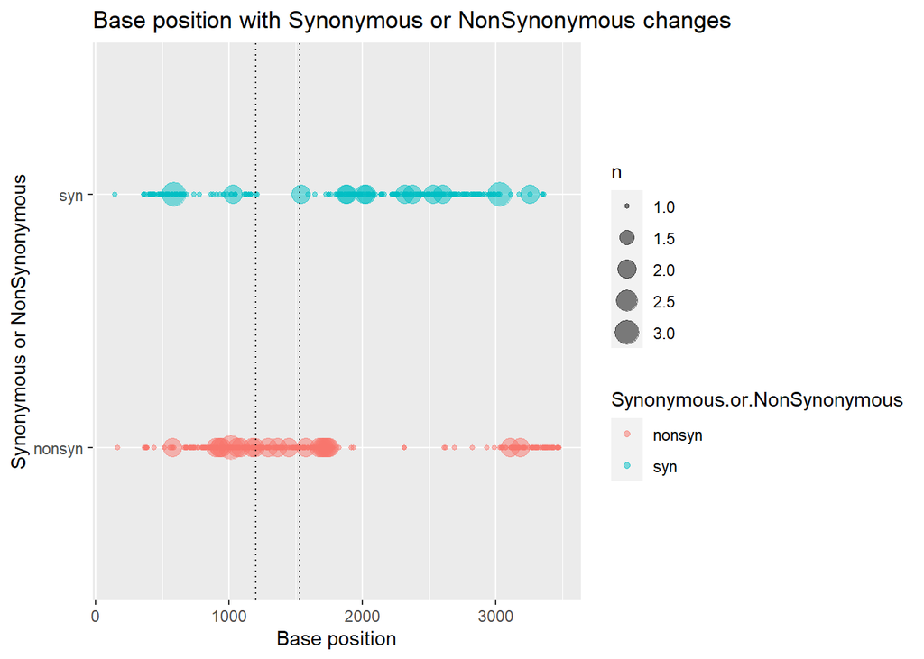

```r
ggplot(data = subdata1, aes(x=Base.Position.of.Change, y=Synonymous.or.NonSynonymous, color=Synonymous.or.NonSynonymous)) +
  geom_count(alpha=0.5)+
  geom_vline(xintercept = c(1200,1530), linetype="dotted")+
   xlab("Base position") +
     ylab("Synonymous or NonSynonymous") +
    ggtitle("Base position with Synonymous or NonSynonymous changes") +
  NULL
```

#For visualiztion of antibodiesand their escape rates

```r
antibodyescapemut<-read.csv("C:/Users/awila/OneDrive/Documents/GitHub/MScThesis/R/LYCoV016andREGNall.csv", sep=",")
```

```r
names(antibodyescapemut)
```

```
##  [1] "condition"                   "site"
##  [3] "label_site"                  "wildtype"
##  [5] "mutation"                    "protein_chain"
##  [7] "protein_site"                "mut_escape.color.ACE2.bind"
##  [9] "site_total.escape"           "site_max.escape"
## [11] "color_for_mutation"          "mut_escape.color.RBD.expr"
## [13] "mut_escape.color.gray"       "mut_escape.color.func.group"
```

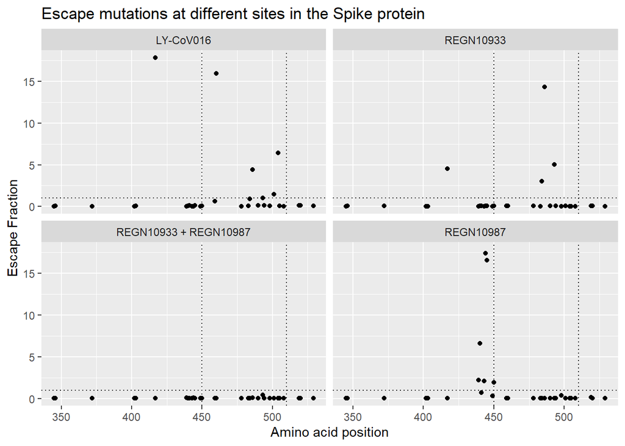

```r
ggplot(antibodyescapemut, aes(label_site, site_total.escape)) +
  geom_point()+
  geom_hline(yintercept = 1, linetype="dotted")+
  geom_vline(xintercept = c(450,510), linetype="dotted")+
  facet_wrap(~condition)+
   xlab("Amino acid position") +
     ylab("Escape Fraction") +
    # xlim(c(400,510)) +
    ggtitle("Escape mutations at different sites in the Spike protein") +
  NULL
```

```r
antibodyescapemut$site_total.escapeoutput <- "No"
antibodyescapemut$site_total.escapeoutput[antibodyescapemut$site_total.escape > 1] <- "Yes"
```

#Escape mutations at different sites in the Spike protein

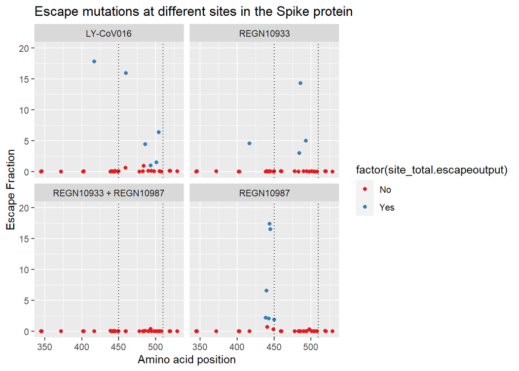

```r
ggplot(antibodyescapemut, aes(label_site, site_total.escape)) +
  geom_point(aes(colour = factor(site_total.escapeoutput)))+
  scale_y_continuous(breaks = seq(0, 20, 5),
                     limits = c(0, 20))+
 scale_color_brewer(palette = "Set1") +
  geom_vline(xintercept = c(450,510), linetype="dotted")+
  facet_wrap(~condition)+
   xlab("Amino acid position") +
     ylab("Escape Fraction") +
    ggtitle("Escape mutations at different sites in the Spike protein") +
  NULL
```

#Escape mutation in RBD region

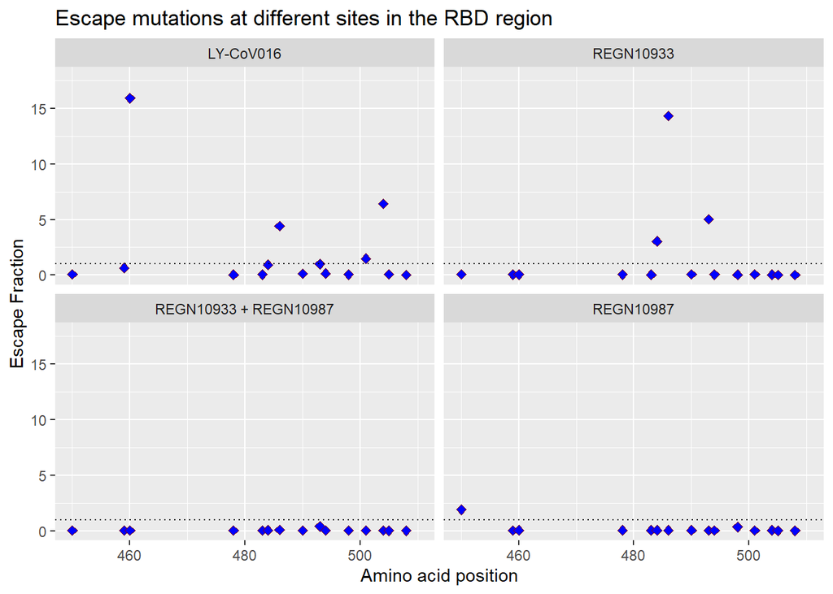

```r
ggplot(antibodyescapemut, aes(label_site, site_total.escape)) +
  geom_point(shape=23, fill="blue", color="darkred", size=2)+
  geom_hline(yintercept = 1, linetype="dotted")+
  facet_wrap(~condition)+
   xlab("Amino acid position") +
     ylab("Escape Fraction") +
     xlim(c(450,510)) +
    ggtitle("Escape mutations at different sites in the RBD region") +
  NULL
```

```r
escdnds <- read.csv("C:/Users/awila/OneDrive/Documents/GitHub/MScThesis/R/EscapeFracanddNdS.csv", sep=",")
names(escdnds)
```

```
## [1] "site"              "wildtype"          "mutation"
## [4] "site_total.escape" "dNdS"
```

```r
escdndsdf <- escdnds %>%
  group_by(site) %>%
  summarise(n          = n(),
            dnds       = median(dNdS),
            esc_frac = median(site_total.escape))
```

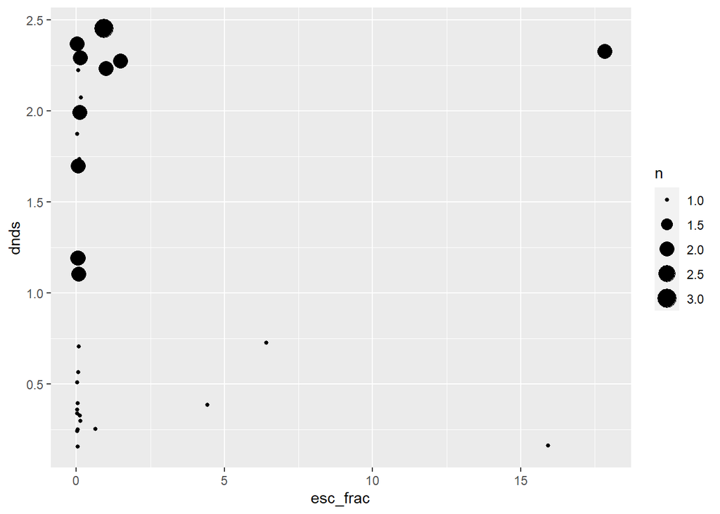

```r
ggplot(data = escdndsdf, mapping = aes(x=esc_frac,y=dnds, size=n)) +
  geom_point() +
  NULL
```

```r
cor(escdndsdf$esc_frac, escdndsdf$dnds, method = "pearson")
```

```
## [1] 0.03248878
```

```r
#install.packages("corrplot")
library(corrplot)
cr <- cor(escdndsdf)
```

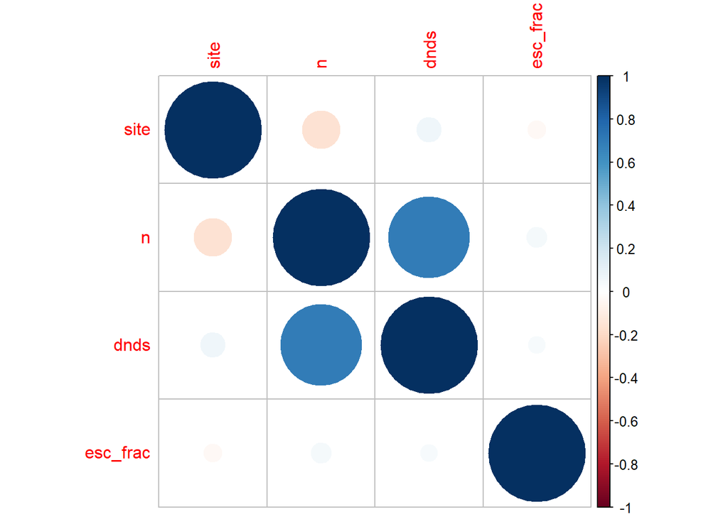

```r
corrplot(cr)
```

Note: Correlation is 0.0325, meaning there is a doubt whether it is a POSITIVE correlation between escape-fraction of mutation and dnds or there is no correlation between them as the correlation is very close to 0. So, the correlation test should be performed.

#Testing the correlation

```r
cor.test(escdndsdf$esc_frac, escdndsdf$dnds, alternative = "two.sided", method = "pearson", conf.level = 0.95, continuity = FALSE)
```

```
##
##  Pearson's product-moment correlation
##
## data:  escdndsdf$esc_frac and escdndsdf$dnds
## t = 0.17505, df = 29, p-value = 0.8623
## alternative hypothesis: true correlation is not equal to 0
## 95 percent confidence interval:
##  -0.3255997  0.3824264
## sample estimates:
##        cor
## 0.03248878
```

Note: If p-value <= 0.05; it is statistically significant and we should reject the null hypothesis. Here, p-value >0.05 so we do not reject the null hypothesis (H0: correlation is 0). So, there is no significant correlation between escape-fraction of mutation and dnds.

```r
dfregression <- lm(dnds ~ esc_frac, data = escdndsdf)
```

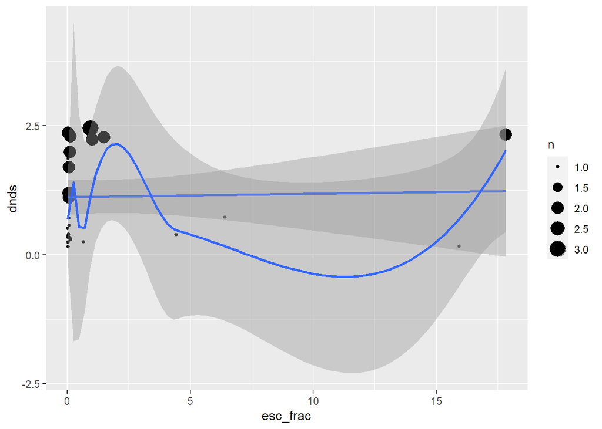

```r
ggplot(data = escdndsdf, mapping = aes(x=esc_frac, y=dnds)) +
  geom_point(aes(size=n)) +
  geom_smooth(method="lm")+
  geom_smooth(method="loess") +
  NULL
```

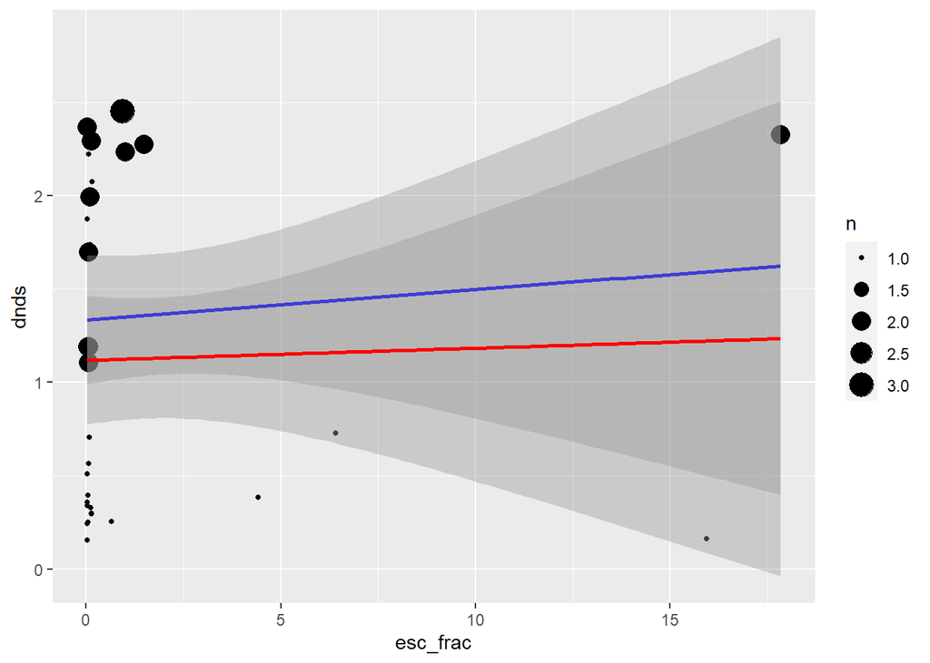

```r
ggplot(data = escdndsdf, mapping = aes(x=esc_frac, y=dnds)) +
  geom_point(aes(size=n)) +
  geom_smooth(aes(weight = n), color="blue", method="lm", show.legend = F) +
  geom_smooth(aes(weight = 1), color="red",  method="lm", show.legend = F) +
  NULL
```